# Informe Estadístico Regional Educativo

2023-05-09

# Establecimientos

Filtramos los datos del Mineduc para la región de O’Higgins. Además, nos quedamos sólo con los establecimientos educacionales que estén funcionando y tengan matrícula. Esto nos deja con 684 establecimientos educacionales.

## Dependencia

NOTAS: 1) Agregar nota al pie sobre SLEP, 2) consideré los Corp. de Admin. Delegada

Comenzamos caracterizando la dependencia a nivel regional.

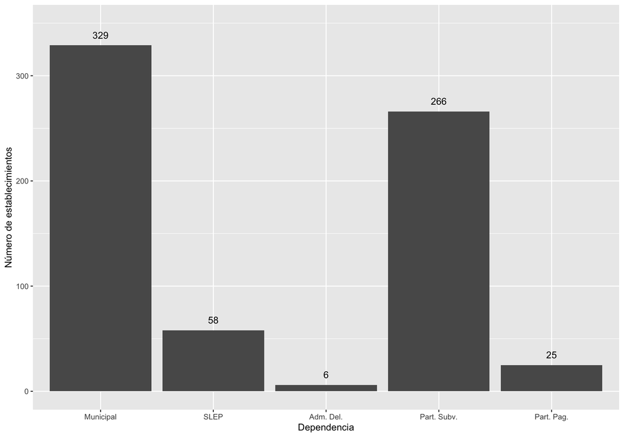

También podemos ver como se distribuye la dependencia dentro de cada provincia.

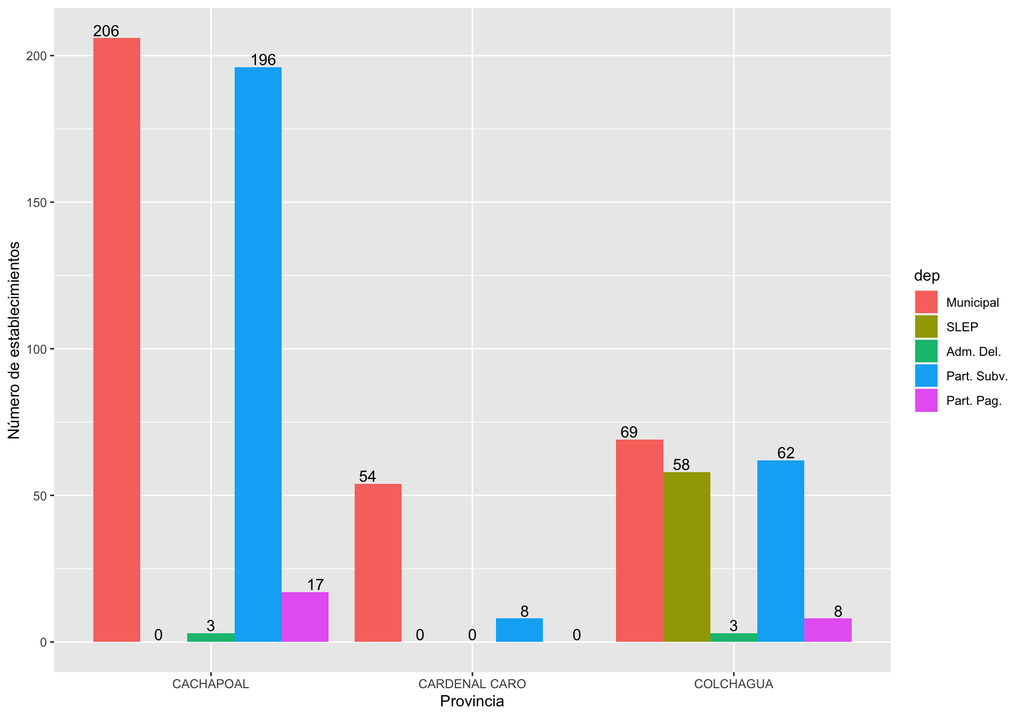

Número de establecimientos según dependencia en cada provincia de la Región de O’Higgins

| Provincia | Municipal | SLEP | Adm. Del. | Part. Subv. | Part. Pag. |
| --- | --- | --- | --- | --- | --- |
| CACHAPOAL | 206 | 0 | 3 | 196 | 17 |
| CARDENAL CARO | 54 | 0 | 0 | 8 | 0 |
| COLCHAGUA | 69 | 58 | 3 | 62 | 8 |
| Total Región | 329 | 58 | 6 | 266 | 25 |

### Ruralidad

Número de establecimientos según ruralidad en cada provincia de la Región de O’Higgins

| Provincia | Número de EE urbanos | Número de EE rurales | % de EE rurales |
| --- | --- | --- | --- |
| CACHAPOAL | 303 | 119 | 28.2 |
| CARDENAL CARO | 21 | 41 | 66.1 |
| COLCHAGUA | 109 | 91 | 45.5 |
| Total Región | 433 | 251 | 36.7 |

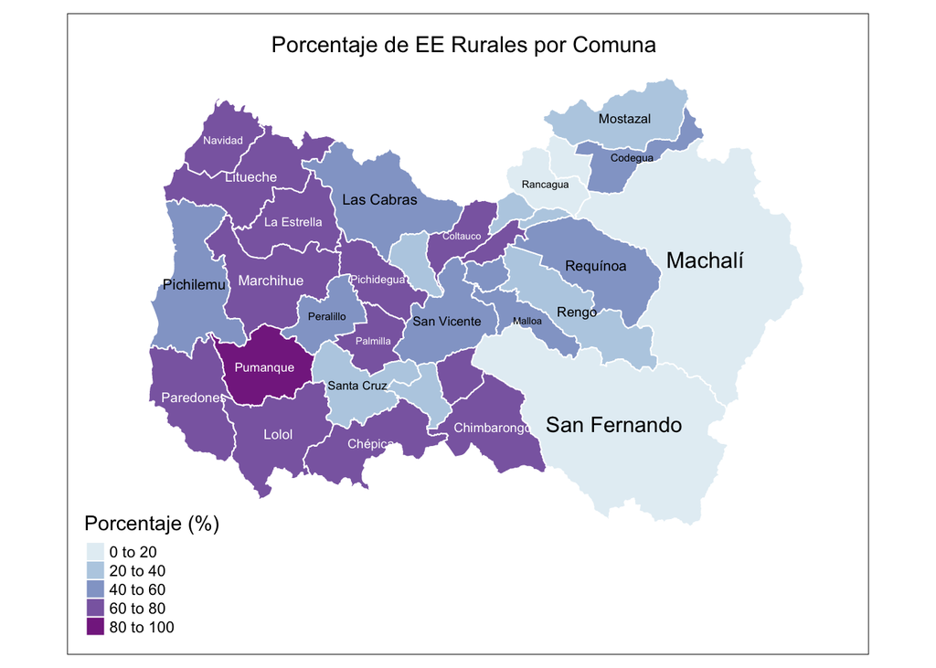

### Modalidades de enseñanza

Nos restringimos a colegios de enseñanza media jóvenes. Separamos en las categorías HC, TP y Polivalente (notar que un colegio Polivalente no cuenta como HC ni como TP).

Número de establecimientos según rama en cada provincia de la Región de O’Higgins

| Provincia | HC | Polivalente | TP | Otros |
| --- | --- | --- | --- | --- |
| CACHAPOAL | 79 | 29 | 5 | 309 |
| CARDENAL CARO | 4 | 3 | 0 | 55 |
| COLCHAGUA | 22 | 12 | 3 | 163 |
| Total Región | 105 | 44 | 8 | 527 |

Podemos ver también los datos por provincia.

```
##   NOM_DEPROV_RBD HC TP POLI TOT_PROV
## 1      CACHAPOAL 79  5   29      113
## 2  CARDENAL CARO  4  0    3        7
## 3      COLCHAGUA 22  3   12       37
```

# Estudiantes

Hacemos un análisis similar al anterior pero ahora a nivel de estudiantes.

En la región de O’Higgins hay un total de 198,956 estudiantes. Veamos como se distribuyen por provincia.

```
##
##     CACHAPOAL CARDENAL CARO     COLCHAGUA
##        140303          8972         49681
```

## Dependencia

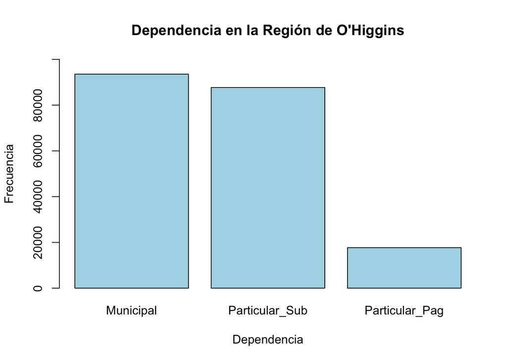

## Ruralidad

En la siguiente tabla podemos ver el porcentaje de estudiantes rural por provincia. Notar las diferencias con el porcentaje de establecimientos rurales.

```
##         Group.1 RURAL_RBD
## 1     CACHAPOAL  14.20283
## 2 CARDENAL CARO  32.61257
## 3     COLCHAGUA  19.29108
```

[figure not shown]

## Modalidades de Enseñanza

Consideramos sólo las modalidades de enseñanza para jóvenes.

```
##                              Var1  Freq
## 5          Humanístico-Científica 40118
## 7 Técnico Profesional y Artística 11757
```

# Docentes

Hacemos un análisis similar a nivel docentes en la región de O’Higgins. Nos quedamos con los docentes cuya función principal es la de “Docente de aula” y que estén en establecimientos funcionando.

Hay un rotal de 12788 en la región de O’Higgins. Se distribuyen de la siguiente forma a lo largo de las tres provinicas de la zona:

```
##               total
## CACHAPOAL      8695
## CARDENAL CARO   691
## COLCHAGUA      3402
```

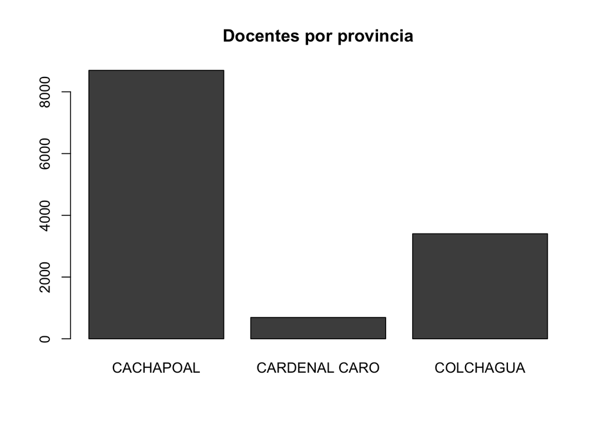

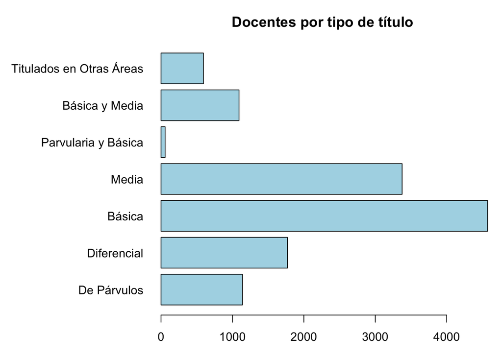

```
##        total
## Hombre  3403
## Mujer   9385
```

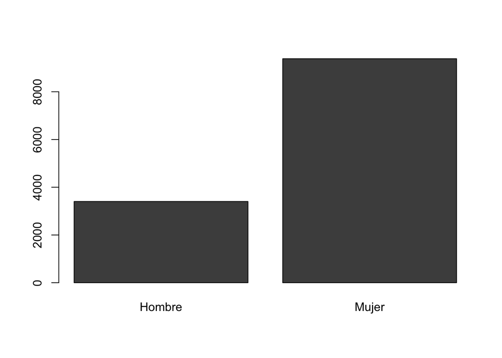